# Final_Proj

## Import the libraries

```python
import numpy as np
import pandas as pd
import random
%matplotlib inline
import matplotlib as mp
import matplotlib.pyplot as plt
import seaborn as sns
import collections
from wordcloud import WordCloud,STOPWORDS
import re
from tqdm import tqdm_notebook, tnrange
from tqdm.auto import tqdm
from keras.preprocessing.text import Tokenizer
from keras_preprocessing.sequence import pad_sequences
import torch.nn as nn
from torch.utils.data import Dataset, DataLoader
import torch
import time
from sklearn.model_selection import StratifiedKFold
from sklearn.metrics import f1_score
from nltk.corpus import stopwords
from sklearn.metrics import classification_report
from sklearn.metrics import confusion_matrix
import nltk
from nltk.stem import WordNetLemmatizer
from nltk.tokenize.toktok import ToktokTokenizer
import warnings
warnings.filterwarnings("ignore")
```

```python
import os
os.getcwd()
```

```
'C:\\Users\\dzfal\\OneDrive\\Desktop\\2023spring\\ML\\Final Proj'
```

## Parameters

```python
embedding_dim = 300 # how big is each word vector
vocab_size = 150000 # how many unique words to use (i.e num rows in embedding vector)
maxlen = 70 # max number of words in a question to use
# Decide which device we want to run on
tagset_size = 1
```

## Data Analysis

### 2.1 Exploring data

#### 2.1.1 Import data

```python
train_df = pd.read_csv('quora-insincere-questions-classification/train.csv')
test_df = pd.read_csv('quora-insincere-questions-classification/test.csv')
```

```python
test_df
```

[output not shown]

#### 2.1.2 Data overview

```python
train_df.head()
```

|  | qid | question_text | target |
| --- | --- | --- | --- |
| 0 | 00002165364db923c7e6 | How did Quebec nationalists see their province... | 0 |
| 1 | 000032939017120e6e44 | Do you have an adopted dog, how would you enco... | 0 |
| 2 | 0000412ca6e4628ce2cf | Why does velocity affect time? Does velocity a... | 0 |
| 3 | 000042bf85aa498cd78e | How did Otto von Guericke used the Magdeburg h... | 0 |
| 4 | 0000455dfa3e01eae3af | Can I convert montra helicon D to a mountain b... | 0 |

```python
train_df.tail()
```

|  | qid | question_text | target |
| --- | --- | --- | --- |
| 1306117 | ffffcc4e2331aaf1e41e | What other technical skills do you need as a c... | 0 |
| 1306118 | ffffd431801e5a2f4861 | Does MS in ECE have good job prospects in USA ... | 0 |
| 1306119 | ffffd48fb36b63db010c | Is foam insulation toxic? | 0 |
| 1306120 | ffffec519fa37cf60c78 | How can one start a research project based on ... | 0 |
| 1306121 | ffffed09fedb5088744a | Who wins in a battle between a Wolverine and a... | 0 |

```python
train_df.info()
```

```
<class 'pandas.core.frame.DataFrame'>
RangeIndex: 1306122 entries, 0 to 1306121
Data columns (total 3 columns):
 #   Column         Non-Null Count    Dtype
---  ------         --------------    -----
 0   qid            1306122 non-null  object
 1   question_text  1306122 non-null  object
 2   target         1306122 non-null  int64
dtypes: int64(1), object(2)
memory usage: 29.9+ MB
```

The dataset has 1306122 questions

```python
train_df[train_df['target']==0].head()
```

|  | qid | question_text | target |
| --- | --- | --- | --- |
| 0 | 00002165364db923c7e6 | How did Quebec nationalists see their province... | 0 |
| 1 | 000032939017120e6e44 | Do you have an adopted dog, how would you enco... | 0 |
| 2 | 0000412ca6e4628ce2cf | Why does velocity affect time? Does velocity a... | 0 |
| 3 | 000042bf85aa498cd78e | How did Otto von Guericke used the Magdeburg h... | 0 |
| 4 | 0000455dfa3e01eae3af | Can I convert montra helicon D to a mountain b... | 0 |

```python
train_df[train_df['target']==1].head()
```

|  | qid | question_text | target |
| --- | --- | --- | --- |
| 22 | 0000e91571b60c2fb487 | Has the United States become the largest dicta... | 1 |
| 30 | 00013ceca3f624b09f42 | Which babies are more sweeter to their parents... | 1 |
| 110 | 0004a7fcb2bf73076489 | If blacks support school choice and mandatory ... | 1 |
| 114 | 00052793eaa287aff1e1 | I am gay boy and I love my cousin (boy). He is... | 1 |
| 115 | 000537213b01fd77b58a | Which races have the smallest penis? | 1 |

### 2.2 Visualization

#### 2.2.1 Statistics on dataset

```python
labels = collections.Counter(train_df['target']).keys()
amounts = collections.Counter(train_df['target']).values()
labels, amounts
```

```
(dict_keys([0, 1]), dict_values([1225312, 80810]))
```

```
(80810, 3) (1225312, 3)
--------------------------
```

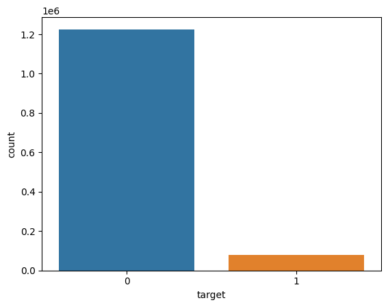

```python
insincere_data_train = train_df[train_df.target == 1]
sincere_data_train = train_df[train_df.target == 0]
print(insincere_data_train.shape, sincere_data_train.shape)
print("--------------------------")

sns.countplot(x='target', data=train_df)
```

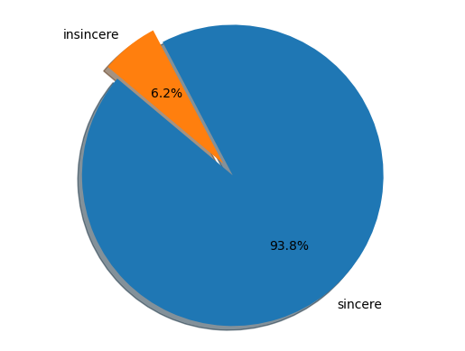

```python
sincere_percent= (len(train_df.question_text[train_df['target'] == 0]) /  len(train_df['question_text']) * 100)
insincere_percent= (len(train_df.question_text[train_df['target'] == 1]) / len(train_df['question_text']) * 100)
__labels = 'sincere', 'insincere'
sizes = [sincere_percent, insincere_percent]
explode = (0.1, 0)  # explode 1st slice

plt.pie(sizes, explode=explode, labels=__labels,autopct='%1.1f%%', shadow=True, startangle=140)

plt.axis('equal')
plt.show()
```

Notice that "sincere question" has more than 1.2 million questions, accounting for 93.8% of the training set, and the remaining 6.2% for "insincere question" with about 81,000 questions. Notice that there is a big difference in the amount of data when the number of "sincere questions" is 15 times that of "insincere questions". With this amount of unbalanced data between labels like this, we need to have a remedy for the imbalance in order for the model to give the best results.

### 2.2.1 Sentence analysis in data

#### Count the number of characters in each sentence

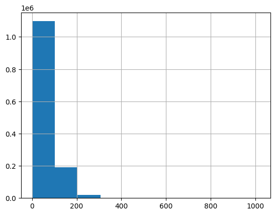

```python
train_df['question_text'].str.len().hist()
```

#### Number of words in a sentence

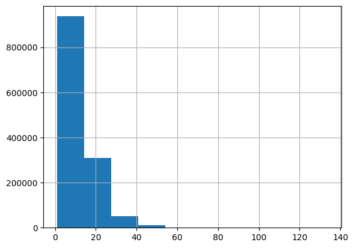

```python
train_df['question_text'].str.split().map(lambda x: len(x)).hist()
```

#### Let's take a look at the words that appear most often in the questions of the data

```
[Text(0.5, 1.0, 'Words that appear most frequently in the traning data')]
```

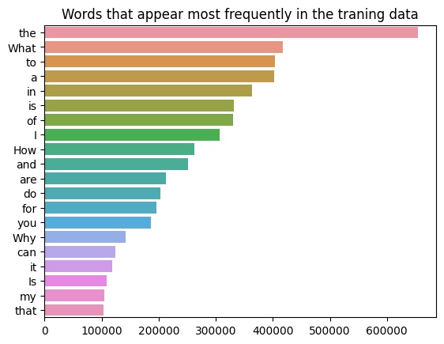

```python
new_corpus = []
quest = train_df['question_text'].str.split()
quest = quest.values.tolist()
new_corpus = [word for q in quest for word in q]
counter = collections.Counter(new_corpus)
most = counter.most_common()

x,y= [],[]
for word,count in most[:20]:
    x.append(word)
    y.append(count)

sns.barplot(x=y,y=x).set(title='Words that appear most frequently in the traning data')
```

```
[Text(0.5, 1.0, 'Words that appear most frequently in the test data')]
```

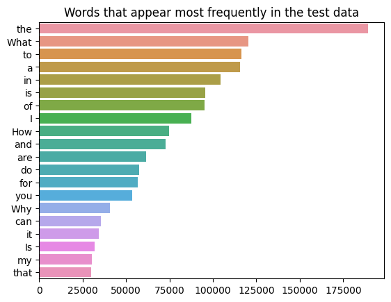

```python
new_corpus = []
quest = test_df['question_text'].str.split()
quest = quest.values.tolist()
new_corpus = [word for q in quest for word in q]
counter = collections.Counter(new_corpus)
most = counter.most_common()

x,y= [],[]
for word,count in most[:20]:
    x.append(word)
    y.append(count)

sns.barplot(x=y,y=x).set(title='Words that appear most frequently in the test data')
```

#### See phrases that appear frequently in questions

```python
def bigrams_data(data):
    bigrams = []
    for question in data:
        question = [w for w in question.lower().split() if w not in STOPWORDS]
        if not question:
            continue
        bi = [b for b in nltk.bigrams(question)]
        bi = [' '.join(w) for w in bi]
        bigrams.extend(bi)
    return bigrams

def draw_plt(data, title, bar_color, numberOfWordsInTop):
    top_words = collections.Counter(data).most_common(numberOfWordsInTop)

    df_top = pd.DataFrame(top_words, columns=['word', 'count']).sort_values('count')

    plt.barh(df_top['word'].values, df_top['count'].values, orientation='horizontal', color=bar_color)
    plt.title(f'Top words in {title}')

bigrams_sincere = bigrams_data(train_df[train_df['target']==0]['question_text'])
bigrams_insincere = bigrams_data(train_df[train_df['target']==1]['question_text'])
```

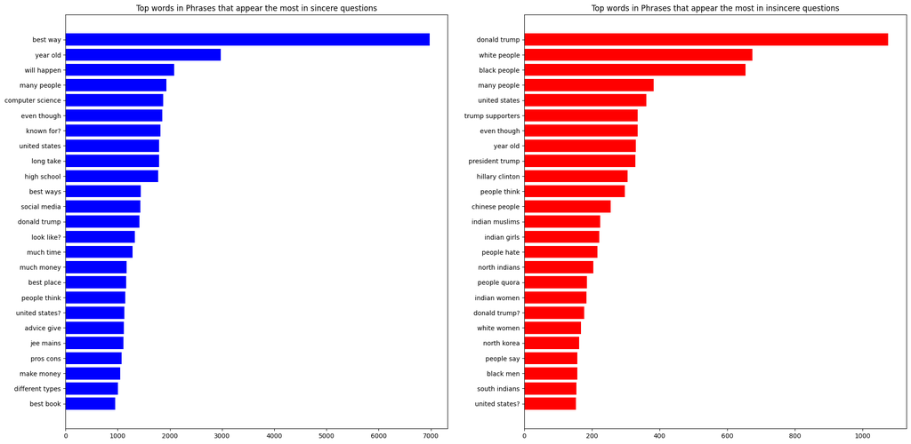

```python
plt.subplot(1, 2, 1)
draw_plt(bigrams_sincere, 'Phrases that appear the most in sincere questions', 'blue',25)


plt.subplot(1, 2, 2)
draw_plt(bigrams_insincere, 'Phrases that appear the most in insincere questions', 'red',25)

plt.subplots_adjust(right=3.0)
plt.subplots_adjust(top=2.0)
plt.show()
```

#### Let's see the words that appear the most in the questions and make a word cloud

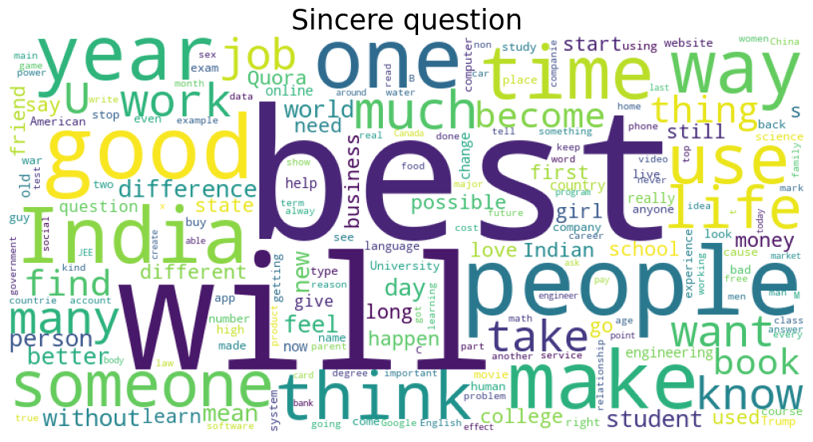

[figure not shown]

```python
def cloud(docs, title):
    wordcloud = WordCloud(width=800, height=400, collocations=False, background_color="white").generate(" ".join(docs))
    fig = plt.figure(figsize=(10,7), facecolor='w')
    plt.imshow(wordcloud)
    plt.axis('off')
    plt.title(title, fontsize=25,color='k')
    plt.tight_layout(pad=0)
    plt.show()
cloud(train_df[train_df['target']==0]['question_text'], "Sincere question")
cloud(test_df['question_text'][train_df['target']==1], "Insincere question")
```

## 2.3 Data preprocessing

```python
# Reference: https://www.kaggle.com/sunnymarkliu/more-text-cleaning-to-increase-word-coverage
```

### 2.3.1 Data cleaning

clean_text: handling special characters that exist in the input text. Special characters are taken from the underlying puncts array. Simple understanding is to remove special characters and remove punctuation

clean_number : Process input digits, replace with #s characters because embedding libraries already handle numbers this way\

replace_typical_misspell : process abbreviations in input sentences with the corresponding mispell_dict

```python
puncts = [',', '.', '"', ':', ')', '(', '-', '!', '?', '|', ';', "'", '$', '&', '/', '[', ']', '>', '%', '=', '#', '*', '+', '\\', '•',  '~', '@', '£',
 '·', '_', '{', '}', '©', '^', '®', '`',  '<', '→', '°', '€', '™', '›',  '♥', '←', '×', '§', '″', '′', 'Â', '█', '½', 'à', '…',
 '“', '★', '”', '–', '●', 'â', '►', '−', '¢', '²', '¬', '░', '¶', '↑', '±', '¿', '▾', '═', '¦', '║', '―', '¥', '▓', '—', '‹', '─',
 '▒', '：', '¼', '⊕', '▼', '▪', '†', '■', '’', '▀', '¨', '▄', '♫', '☆', 'é', '¯', '♦', '¤', '▲', 'è', '¸', '¾', 'Ã', '⋅', '‘', '∞',
 '∙', '）', '↓', '、', '│', '（', '»', '，', '♪', '╩', '╚', '³', '・', '╦', '╣', '╔', '╗', '▬', '❤', 'ï', 'Ø', '¹', '≤', '‡', '√', ]
punct_mapping = {"‘": "'", "₹": "e", "´": "'", "°": "", "€": "e", "™": "tm", "√": " sqrt ", "×": "x", "²": "2",
                 "—": "-", "–": "-", "’": "'", "_": "-", "`": "'", '”': '"', '“': '"', "£": "e",
                 '∞': 'infinity', 'θ': 'theta', '÷': '/', 'α': 'alpha', '•': '.', 'à': 'a', '−': '-', 'β': 'beta',
                 '∅': '', '³': '3', 'π': 'pi', '\u200b': ' ', '…': ' ... ', '\ufeff': '', 'करना': '', 'है': ''}
for p in puncts:
    punct_mapping[p] = ' %s ' % p

p = re.compile('(\[ math \]).+(\[ / math \])')
p_space = re.compile(r'[^\x20-\x7e]')

#Remove stop word
def remove_stopwords(text):
    text = [word for word in text.split() if word not in STOPWORDS]
    text = ' '.join(text)
    return text

def clean_text(text):
    # clean latex maths
    text = p.sub(' [ math ] ', text)
    # clean invisible chars
    text = p_space.sub(r'', text)
    # clean punctuations
    for punct in punct_mapping:
        if punct in text:
            text = text.replace(punct, punct_mapping[punct])
    #Remove stop word
#     text = remove_stopwords(text)
    return text

def clean_numbers(x):
    if bool(re.search(r'\d', x)):
        x = re.sub('[0-9]{5,}', '#####', x)
        x = re.sub('[0-9]{4}', '####', x)
        x = re.sub('[0-9]{3}', '###', x)
        x = re.sub('[0-9]{2}', '##', x)
    return x

mispell_dict = {"ain't": "is not", "aren't": "are not", "can't": "cannot", "'cause": "because",
                "could've": "could have", "couldn't": "could not", "didn't": "did not", "doesn't": "does not",
                "don't": "do not", "hadn't": "had not", "hasn't": "has not", "haven't": "have not",
                "he'd": "he would", "he'll": "he will", "he's": "he is", "how'd": "how did",
                "how'd'y": "how do you", "how'll": "how will", "how's": "how is", "i'd": "i would",
                "i'd've": "i would have", "i'll": "i will", "i'll've": "I will have", "i'm": "i am",
                "i've": "I have", "isn't": "is not", "it'd": "it would",
                "it'd've": "it would have", "it'll": "it will", "it'll've": "it will have", "it's": "it is",
                "let's": "let us", "ma'am": "madam", "mayn't": "may not", "might've": "might have",
                "mightn't": "might not", "mightn't've": "might not have", "must've": "must have",
                "mustn't": "must not", "mustn't've": "must not have", "needn't": "need not",
                "needn't've": "need not have", "o'clock": "of the clock", "oughtn't": "ought not",
                "oughtn't've": "ought not have", "shan't": "shall not", "sha'n't": "shall not",
                "shan't've": "shall not have", "she'd": "she would", "she'd've": "she would have",
                "she'll": "she will", "she'll've": "she will have", "she's": "she is",
                "should've": "should have", "shouldn't": "should not", "shouldn't've": "should not have",
                "so've": "so have", "so's": "so as", "this's": "this is", "that'd": "that would",
                "that'd've": "that would have", "that's": "that is", "there'd": "there would",
                "there'd've": "there would have", "there's": "there is", "here's": "here is",
                "they'd": "they would", "they'd've": "they would have", "they'll": "they will",
                "they'll've": "they will have", "they're": "they are", "they've": "they have",
                "to've": "to have", "wasn't": "was not", "we'd": "we would", "we'd've": "we would have",
                "we'll": "we will", "we'll've": "we will have", "we're": "we are", "we've": "we have",
                "weren't": "were not", "what'll": "what will", "what'll've": "what will have",
                "what're": "what are", "what's": "what is", "what've": "what have", "when's": "when is",
                "when've": "when have", "where'd": "where did", "where's": "where is", "where've": "where have",
                "who'll": "who will", "who'll've": "who will have", "who's": "who is", "who've": "who have",
                "why's": "why is", "why've": "why have", "will've": "will have", "won't": "will not",
                "won't've": "will not have", "would've": "would have", "wouldn't": "would not",
                "wouldn't've": "would not have", "y'all": "you all", "y'all'd": "you all would",
                "y'all'd've": "you all would have", "y'all're": "you all are", "y'all've": "you all have",
                "you'd": "you would", "you'd've": "you would have", "you'll": "you will",
                "you'll've": "you will have", "you're": "you are", "you've": "you have", 'colour': 'color',
                'centre': 'center', 'favourite': 'favorite', 'travelling': 'traveling',
                'counselling': 'counseling', 'theatre': 'theater', 'cancelled': 'canceled', 'labour': 'labor',
                'organisation': 'organization', 'wwii': 'world war 2', 'citicise': 'criticize',
                'youtu ': 'youtube ', 'qoura': 'quora', 'sallary': 'salary', 'whta': 'what',
                'narcisist': 'narcissist', 'howdo': 'how do', 'whatare': 'what are', 'howcan': 'how can',
                'howmuch': 'how much', 'howmany': 'how many', 'whydo': 'why do', 'doi': 'do I',
                'thebest': 'the best', 'howdoes': 'how does', 'mastrubation': 'masturbation',
                'mastrubate': 'masturbate', "mastrubating": 'masturbating', 'pennis': 'penis',
                'etherium': 'ethereum', 'narcissit': 'narcissist', 'bigdata': 'big data', '2k17': '2017',
                '2k18': '2018', 'qouta': 'quota', 'exboyfriend': 'ex boyfriend', 'airhostess': 'air hostess',
                "whst": 'what', 'watsapp': 'whatsapp', 'demonitisation': 'demonetization',
                'demonitization': 'demonetization', 'demonetisation': 'demonetization'}
#Removing Contractions
def replace_typical_misspell(text):
    tokens = []
    for token in text.split():
        # replace contractions & correct misspells
        token = mispell_dict.get(token.lower(), token)
        tokens.append(token)
    text = ' '.join(tokens)
    return text

#Remove contraction
contraction_map = {"ain't": "is not", "aren't": "are not","can't": "cannot", "'cause": "because", "could've": "could have", "couldn't": "could not", "didn't": "did not",  "doesn't": "does not", "don't": "do not", "hadn't": "had not", "hasn't": "has not", "haven't": "have not", "he'd": "he would","he'll": "he will", "he's": "he is", "how'd": "how did", "how'd'y": "how do you", "how'll": "how will", "how's": "how is",  "I'd": "I would", "I'd've": "I would have", "I'll": "I will", "I'll've": "I will have","I'm": "I am", "I've": "I have", "i'd": "i would", "i'd've": "i would have", "i'll": "i will",  "i'll've": "i will have","i'm": "i am", "i've": "i have", "isn't": "is not", "it'd": "it would", "it'd've": "it would have", "it'll": "it will", "it'll've": "it will have","it's": "it is", "let's": "let us", "ma'am": "madam", "mayn't": "may not", "might've": "might have","mightn't": "might not","mightn't've": "might not have", "must've": "must have", "mustn't": "must not", "mustn't've": "must not have", "needn't": "need not", "needn't've": "need not have","o'clock": "of the clock", "oughtn't": "ought not", "oughtn't've": "ought not have", "shan't": "shall not", "sha'n't": "shall not", "shan't've": "shall not have", "she'd": "she would", "she'd've": "she would have", "she'll": "she will", "she'll've": "she will have", "she's": "she is", "should've": "should have", "shouldn't": "should not", "shouldn't've": "should not have", "so've": "so have","so's": "so as", "this's": "this is","that'd": "that would", "that'd've": "that would have", "that's": "that is", "there'd": "there would", "there'd've": "there would have", "there's": "there is", "here's": "here is","they'd": "they would", "they'd've": "they would have", "they'll": "they will", "they'll've": "they will have", "they're": "they are", "they've": "they have", "to've": "to have", "wasn't": "was not", "we'd": "we would", "we'd've": "we would have", "we'll": "we will", "we'll've": "we will have", "we're": "we are", "we've": "we have", "weren't": "were not", "what'll": "what will", "what'll've": "what will have", "what're": "what are",  "what's": "what is", "what've": "what have", "when's": "when is", "when've": "when have", "where'd": "where did", "where's": "where is", "where've": "where have", "who'll": "who will", "who'll've": "who will have", "who's": "who is", "who've": "who have", "why's": "why is", "why've": "why have", "will've": "will have", "won't": "will not", "won't've": "will not have", "would've": "would have", "wouldn't": "would not", "wouldn't've": "would not have", "y'all": "you all", "y'all'd": "you all would","y'all'd've": "you all would have","y'all're": "you all are","y'all've": "you all have","you'd": "you would", "you'd've": "you would have", "you'll": "you will", "you'll've": "you will have", "you're": "you are", "you've": "you have" }
def clean_contractions(text):
    specials = ["’", "‘", "´", "`"]
    for s in specials:
        text = text.replace(s, "'")

    text = ' '.join([contraction_map[t] if t in contraction_map else t for t in text.split(" ")])
    return text
```

### 2.3.2 Data Normalization

1. Convert all characters in question to lowercase
2. Remove special characters from each sentence
3. Deal with the digits in each question
4. Replace acronyms in their original form
5. Replace null values in question text column with value
6. Add some data fields to the dataset
7. Tokenize train data and test data : Convert text -> word matrix

Padding data : Models require same input size -> Fill sentences with few words (short matrix)  
Shuffle data: shuffle data randomly

```python
from sklearn.preprocessing import StandardScaler
tqdm.pandas()
# Add features
def add_features(df):

    df['question_text'] = df['question_text'].progress_apply(lambda x:str(x))
    df['total_length'] = df['question_text'].progress_apply(len)
    df['capitals'] = df['question_text'].progress_apply(lambda comment: sum(1 for c in comment if c.isupper()))
    df['caps_vs_length'] = df.progress_apply(lambda row: float(row['capitals'])/float(row['total_length']),
                                axis=1)
    df['num_words'] = df.question_text.str.count('\S+')
    df['num_unique_words'] = df['question_text'].progress_apply(lambda comment: len(set(w for w in comment.split())))
    df['words_vs_unique'] = df['num_unique_words'] / df['num_words']

    return df

def train_test_splitting():
    print("Train shape : ",train_df.shape)
    print("Test shape : ",test_df.shape)


    # Lower
    train_df["question_text"] = train_df["question_text"].apply(lambda x: x.lower())
    test_df["question_text"] = test_df["question_text"].apply(lambda x: x.lower())

    # Clean the text
    train_df["question_text"] = train_df["question_text"].progress_apply(lambda x: clean_text(x))
    test_df["question_text"] = test_df["question_text"].apply(lambda x: clean_text(x))
    # Clean numbers
    train_df["question_text"] = train_df["question_text"].progress_apply(lambda x: clean_numbers(x))
    test_df["question_text"] = test_df["question_text"].apply(lambda x: clean_numbers(x))

    # Clean speelings
    train_df["question_text"] = train_df["question_text"].progress_apply(lambda x: replace_typical_misspell(x))
    test_df["question_text"] = test_df["question_text"].apply(lambda x: replace_typical_misspell(x))

    # Fill up the missing values
    train_X = train_df["question_text"].fillna("_##_").values
    test_X = test_df["question_text"].fillna("_##_").values
    ###################### Add Features ###############################
    train = add_features(train_df)
    test = add_features(test_df)

    features = train[['caps_vs_length', 'words_vs_unique']].fillna(0)
    test_features = test[['caps_vs_length', 'words_vs_unique']].fillna(0)

    ss = StandardScaler()
    ss.fit(np.vstack((features, test_features)))
    features = ss.transform(features)
    test_features = ss.transform(test_features)
    ###########################################################################

    ## Tokenize the sentences
    tokenizer = Tokenizer(num_words=vocab_size)
    tokenizer.fit_on_texts(list(train_X))
    train_X = tokenizer.texts_to_sequences(train_X)
    test_X = tokenizer.texts_to_sequences(test_X)

    ## Pad the sentences
    train_X = pad_sequences(train_X, maxlen=maxlen)
    test_X = pad_sequences(test_X, maxlen=maxlen)

    ## Get the target values
    train_y = train_df['target'].values


    #shuffling the data
    np.random.seed(2023)
    trn_idx = np.random.permutation(len(train_X))

    train_X = train_X[trn_idx]
    train_y = train_y[trn_idx]
    features = features[trn_idx]

    return train_X, test_X, train_y
```

```python
x_train, x_test, y_train = train_test_splitting()
```

[output not shown]

### 2.3.3 Embedding

I use 3 embedding libraries from available Google-glove, Facebook-fasttext, paragram  
Reference:https://www.kaggle.com/suicaokhoailang/blending-with-linear-regression-0-688-lb/notebook

```python
def load_glove(word_index):
    EMBEDDING_FILE = 'quora-insincere-questions-classification/embeddings/glove.840B.300d/glove.840B.300d.txt'
    def get_coefs(word,*arr): return word, np.asarray(arr, dtype='float32')
    embeddings_index = dict(get_coefs(*o.split(" ")) for o in open(EMBEDDING_FILE, encoding="utf-8"))

    all_embs = np.stack(embeddings_index.values())
    emb_mean,emb_std = all_embs.mean(), all_embs.std()
    embed_size = all_embs.shape[1]

    # word_index = tokenizer.word_index
    nb_words = min(vocab_size, len(word_index))
    embedding_matrix = np.random.normal(emb_mean, emb_std, (nb_words, embed_size))
    for word, i in tqdm(word_index.items()):
        if i >= vocab_size: continue
        embedding_vector = embeddings_index.get(word)
        if embedding_vector is not None: embedding_matrix[i] = embedding_vector

    return embedding_matrix

def load_fasttext(word_index):
    EMBEDDING_FILE = 'quora-insincere-questions-classification/embeddings/wiki-news-300d-1M/wiki-news-300d-1M.vec'
    def get_coefs(word,*arr): return word, np.asarray(arr, dtype='float32')
    embeddings_index = dict(get_coefs(*o.split(" ")) for o in open(EMBEDDING_FILE, encoding="utf-8") if len(o)>100)

    all_embs = np.stack(embeddings_index.values())
    emb_mean,emb_std = all_embs.mean(), all_embs.std()
    embed_size = all_embs.shape[1]
    # word_index = tokenizer.word_index
    nb_words = min(vocab_size, len(word_index))
    embedding_matrix = np.random.normal(emb_mean, emb_std, (nb_words, embed_size))
    for word, i in tqdm(word_index.items()):
        if i >= vocab_size: continue
        embedding_vector = embeddings_index.get(word)
        if embedding_vector is not None: embedding_matrix[i] = embedding_vector

    return embedding_matrix

def load_para(word_index):
    EMBEDDING_FILE = 'quora-insincere-questions-classification/embeddings/paragram_300_sl999/paragram_300_sl999.txt'
    def get_coefs(word,*arr): return word, np.asarray(arr, dtype='float32')
    embeddings_index = dict(get_coefs(*o.split(" ")) for o in open(EMBEDDING_FILE, encoding="utf8", errors='ignore') if len(o)>100)

    all_embs = np.stack(embeddings_index.values())
    emb_mean,emb_std = all_embs.mean(), all_embs.std()
    embed_size = all_embs.shape[1]

    # word_index = tokenizer.word_index
    nb_words = min(vocab_size, len(word_index))
    embedding_matrix = np.random.normal(emb_mean, emb_std, (nb_words, embed_size))
    for word, i in tqdm(word_index.items()):
        if i >= vocab_size: continue
        embedding_vector = embeddings_index.get(word)
        if embedding_vector is not None: embedding_matrix[i] = embedding_vector

    return embedding_matrix
```

```python
set_seed()
embedding_matrix_1 = load_glove(word_index)
embedding_matrix_2 = load_fasttext(word_index)
embedding_matrix_3 = load_para(word_index)
```

```python
embedding_matrix = np.mean([embedding_matrix_1, embedding_matrix_2, embedding_matrix_3], axis=0)
np.shape(embedding_matrix)
```

```
(150000, 300)
```

## 3. Model

```python
# Reference: https://www.tensorflow.org/text/tutorials/text_classification_rnn#create_the_model
```

```python
from keras import models
from keras.callbacks import EarlyStopping
from keras.layers import Dense
from keras.layers import Input
from keras.layers import Dropout
from keras.layers import Embedding
from keras.layers import Bidirectional
from keras.layers import LSTM
from keras.layers import Conv1D
from keras.layers import GlobalMaxPool1D
from keras.layers import GRU
```

```python
inputs = Input(shape=(maxlen))
x = Embedding(input_dim=vocab_size, output_dim=embedding_dim,weights=[embedding_matrix], trainable=False)(inputs)
x = Bidirectional(GRU(64, return_sequences=True))(x)
x = GlobalMaxPool1D()(x)
x = Dense(16, activation='relu')(x)
x = Dropout(0.1)(x)
outputs = Dense(1, activation='sigmoid')(x)

model = models.Model(inputs=inputs, outputs=outputs)
model.compile(loss='binary_crossentropy', optimizer='adam', metrics=['accuracy'])
callbacks = [EarlyStopping(monitor='val_loss', patience=2)]

model.summary()
```

```
Model: "model_3"
_________________________________________________________________
 Layer (type)                Output Shape              Param #
=================================================================
 input_8 (InputLayer)        [(None, 70)]              0

 embedding_8 (Embedding)     (None, 70, 300)           45000000

 bidirectional_6 (Bidirectio  (None, 70, 128)          140544
 nal)

 global_max_pooling1d_6 (Glo  (None, 128)              0
 balMaxPooling1D)

 dense_12 (Dense)            (None, 16)                2064

 dropout_6 (Dropout)         (None, 16)                0

 dense_13 (Dense)            (None, 1)                 17

=================================================================
Total params: 45,142,625
Trainable params: 142,625
Non-trainable params: 45,000,000
_________________________________________________________________
```

```python
history = model.fit(x_train,y_train, epochs = 3, validation_split = 0.2, callbacks = callbacks, verbose = 1,batch_size = 256)
# Print results.
history = history.history
```

[output not shown]